# Benchmarking Pv3Rs

In this document, we investigate the runtime scaling of the `Pv3Rs`’ main function, `compute_posterior`, with respect to the number of markers, the MOIs, and the number of episodes.

## Setup

```r
library(Pv3Rs)
library(tictoc)
library(MCMCpack)

# simulate allele frequencies for one marker
sim_fs_single <- function(n_a) {
  alleles <- letters[1:n_a] # n_a <= 26
  fs_unnamed <- as.vector(rdirichlet(1, alpha = rep(1, n_a)))
  setNames(fs_unnamed, alleles)
}

# simulate allele frequencies for multiple markers
# assumes each marker has the same number of alleles
sim_fs <- function(n_m, n_a) {
  markers <- paste0("m", 1:n_m) # marker names
  n_a_vec <- setNames(rep(n_a, n_m), markers)
  lapply(n_a_vec, sim_fs_single)
}

# simulate data for one marker, one episode
# sample without replacement to match desired MOI, so must have length(fs) >= MOI
sim_data_single <- function(fs_single, MOI) {
  sample(names(fs_single), MOI, prob=fs_single)
}

# simulate data for all markers, all episodes
sim_data <- function(MOIs, n_m, n_a) {
  fs <- sim_fs(n_m, n_a)
  y <- lapply(
    MOIs,
    function(MOI) lapply(fs, sim_data_single, MOI) # sample data for one episode
  )
  return(list(y=y, fs=fs))
}
```

## Runtime vs number of markers

We expect the runtime of `compute_posterior` to scale linearly with the number of markers due to the likelihood decomposition ([1], Section 3.4). We simulate genetic data spanning across 2 episodes both with MOI 2, and vary the number of markers between $50, 100, \cdots, 400$. Each marker is assumed to have 8 possible alleles.

```r
set.seed(1)
n_markers <- 50*(1:8)
n_a <- 8
MOIs <- c(2, 2)
n_rep <- 30

data_by_m <- list()
for (n_m in n_markers) {
  data_by_m[[as.character(n_m)]] <- lapply(
    1:n_rep,
    function(x) sim_data(MOIs, n_m, n_a)
  )
}

time_by_m <- list()
for (n_m in n_markers) {
  tic(msg = paste0("Running n_m=", n_m))
  time_by_m[[as.character(n_m)]] <- sapply(
    data_by_m[[as.character(n_m)]],
    function(data) {
      tic("")
      invisible(capture.output(compute_posterior(data$y, data$fs))) # disable output
      res <- toc(quiet=TRUE)
      res$toc - res$tic
    }
  )
  toc()
}
```

```
#> Running n_m=50: 4.916 sec elapsed
#> Running n_m=100: 7.513 sec elapsed
#> Running n_m=150: 11.543 sec elapsed
#> Running n_m=200: 14.323 sec elapsed
#> Running n_m=250: 18.045 sec elapsed
#> Running n_m=300: 21.395 sec elapsed
#> Running n_m=350: 25.136 sec elapsed
#> Running n_m=400: 29.039 sec elapsed
```

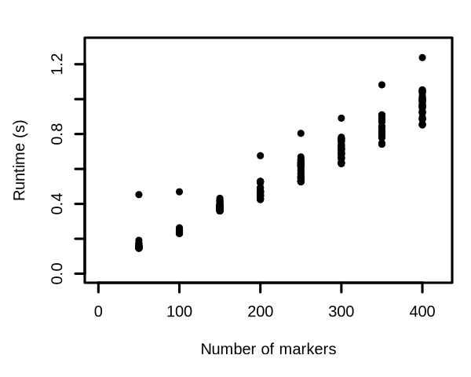

```r
max_time <- max(sapply(time_by_m, max))
par(cex=0.4, mar=c(5, 4.5, 2, 1))
plot(
  NULL, type="n",
  xlim=c(0, 420),
  ylim=c(0, max_time*1.05),
  xlab="Number of markers",
  ylab="Runtime (s)"
)
for(n_m in n_markers) {
  points(rep(n_m, n_rep), time_by_m[[as.character(n_m)]], pch=20)
}
```

## Runtime vs MOIs

As the number of MOIs increase, the runtime increases due to having more possibilities for allele assignment and more valid relationship graphs. We simulate genetic data consisting of 1 marker (8 alleles), spanning 2 episodes of various MOI combinations.

```r
set.seed(1)
n_m <- 1
n_a <- 8
MOIs_comb <- list()
for(MOItot in 3:7) {
  for(MOI1 in (MOItot-1):1) {
    MOI2 <- MOItot-MOI1
    if(MOI1 >= MOI2) MOIs_comb <- c(MOIs_comb, list(c(MOI1, MOI2)))
  }
}
n_rep <- 30

data_by_MOI <- list()
for (MOIs in MOIs_comb) {
  data_by_MOI[[paste(MOIs, collapse=",")]] <- lapply(
    1:n_rep,
    function(x) sim_data(MOIs, n_m, n_a)
  )
}

time_by_MOI <- list()
for (MOIs in MOIs_comb) {
  MOIstr <- paste(MOIs, collapse=",")
  tic(msg = paste0("Running MOI=", MOIstr))
  time_by_MOI[[MOIstr]] <- sapply(
    data_by_MOI[[MOIstr]],
    function(data) {
      tic("")
      invisible(capture.output(compute_posterior(data$y, data$fs))) # disable output
      res <- toc(quiet=TRUE)
      res$toc - res$tic
    }
  )
  toc()
}
```

```
#> Running MOI=2,1: 0.524 sec elapsed
#> Running MOI=3,1: 1.921 sec elapsed
#> Running MOI=2,2: 2.018 sec elapsed
#> Running MOI=4,1: 7.623 sec elapsed
#> Running MOI=3,2: 8.612 sec elapsed
#> Running MOI=5,1: 43.355 sec elapsed
#> Running MOI=4,2: 49.574 sec elapsed
#> Running MOI=3,3: 53.404 sec elapsed
#> Running MOI=6,1: 278.429 sec elapsed
#> Running MOI=5,2: 326.482 sec elapsed
#> Running MOI=4,3: 347.229 sec elapsed
```

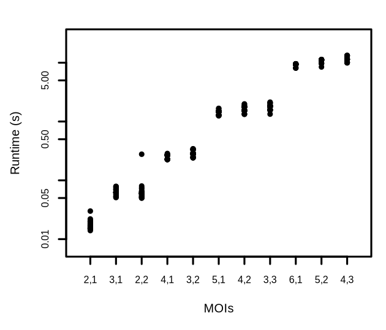

```r
min_time <- min(sapply(time_by_MOI, min))
max_time <- max(sapply(time_by_MOI, max))
n <- length(MOIs_comb)

par(cex=0.4, cex.axis=0.8, mar=c(5, 4.5, 2, 1))
plot(
  1, 1, type="n",
  xlim=c(0.5, n+0.5),
  ylim=c(min_time*0.5, max_time*2),
  xlab="MOIs",
  ylab="Runtime (s)",
  xaxt='n', log="y",
)
axis(
  side=1, at=1:n,
  sapply(MOIs_comb, paste, collapse=",")
)

for(i in 1:n) {
  points(rep(i, n_rep), time_by_MOI[[i]], pch=20)
}
```

Empirically, the runtime (note the log scale) has roughly exponentially scaling with respect to the total MOI. It is difficult to conclude an exact growth rate due to the small range of the total MOI. Given a fixed total MOI, the runtime is slightly shorter (see printed output of total runtime) if the maximum MOI is larger. This can be explained by the following observations:

- A larger maximum MOI leads to more pairs of genotypes that cannot be clones. This leads to less valid relationship graphs to enumerate.
- Allele assignment for the largest MOI is always fixed. A smaller minimum MOI leads to less allele assignment possibilities to be considered.

## Runtime vs number of episodes

Here we investigate two separate cases:

- increasing the number of episodes with 1 genotype per episode, and
- increasing the number of episodes with a fixed total MOI.

### 1 genotype per episode

We simulate genetic data consisting of 1 marker (8 alleles), with 1 genotype per episode for various numbers of episodes.

```r
set.seed(1)
n_m <- 1
n_a <- 8
n_epis <- 2:7
n_rep <- 30

data_by_epi <- list()
for (epi in n_epis) {
  data_by_epi[[as.character(epi)]] <- lapply(
    1:n_rep,
    function(x) sim_data(rep(1, epi), n_m, n_a)
  )
}

time_by_epi <- list()
for (epi in n_epis) {
  tic(msg = paste0("Running epi=", epi))
  time_by_epi[[as.character(epi)]] <- sapply(
    data_by_epi[[as.character(epi)]],
    function(data) {
      tic("")
      invisible(capture.output(compute_posterior(data$y, data$fs))) # disable output
      res <- toc(quiet=TRUE)
      res$toc - res$tic
    }
  )
  toc()
}
```

```
#> Running epi=2: 0.655 sec elapsed
#> Running epi=3: 0.581 sec elapsed
#> Running epi=4: 2.545 sec elapsed
#> Running epi=5: 13.31 sec elapsed
#> Running epi=6: 92.677 sec elapsed
#> Running epi=7: 740.409 sec elapsed
```

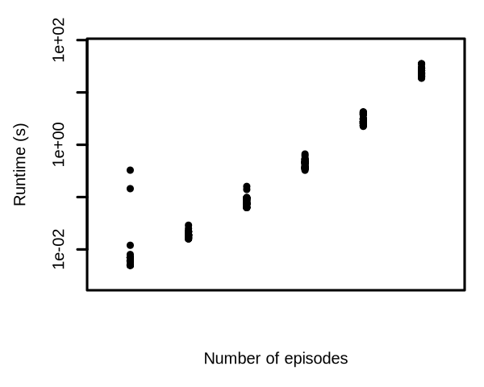

```r
min_time <- min(sapply(time_by_epi, min))
max_time <- max(sapply(time_by_epi, max))

par(cex=0.4, mar=c(5, 4.5, 2, 1))
plot(
  1, 1, type="n",
  xlim=c(1.5, 7.5),
  ylim=c(min_time*0.5, max_time*2),
  xlab="Number of episodes",
  ylab="Runtime (s)",
  xaxt='n', log="y",
)

for(epi in n_epis) {
  points(rep(epi, n_rep), time_by_epi[[as.character(epi)]], pch=20)
}
```

With one genotype per episode, the runtime (note the log scale) scales super-exponentially with respect to the number of episodes (or equivalently, the total MOI). This is expected as the number of relationship graphs with $n$ genotypes is lower bounded by the $n$-th Bell number $B_n$, and it is known that $\log B_n$ scales roughly as $O(n\log n)$.

### Fixed total MOI

We simulate genetic data consisting of 1 marker (8 alleles), for various numbers of episodes with a fixed total MOI of 7. See printed output below for the sequence of MOIs considered.

```r
set.seed(1)
n_m <- 1
n_a <- 8
maxepi <- 7 # fixed total MOI
n_rep <- 30

MOI_fix_comb <- list()
for(epi in 2:maxepi) {
  m <- maxepi %/% epi
  rem <- maxepi %% epi
  MOI_fix_comb <- c(MOI_fix_comb, list(c(rep(m+1, rem), rep(m, epi-rem))))
}

data_by_MOI_fix <- list()
for (MOIs in MOI_fix_comb) {
  data_by_MOI_fix[[paste(MOIs, collapse=",")]] <- lapply(
    1:n_rep,
    function(x) sim_data(MOIs, n_m, n_a)
  )
}

time_by_MOI_fix <- list()
for (MOIs in MOI_fix_comb) {
  MOIstr <- paste(MOIs, collapse=",")
  tic(msg = paste0("Running MOI=", MOIstr))
  time_by_MOI_fix[[MOIstr]] <- sapply(
    data_by_MOI_fix[[MOIstr]],
    function(data) {
      tic("")
      invisible(capture.output(compute_posterior(data$y, data$fs))) # disable output
      res <- toc(quiet=TRUE)
      res$toc - res$tic
    }
  )
  toc()
}
```

```
#> Running MOI=4,3: 360.746 sec elapsed
#> Running MOI=3,2,2: 446.642 sec elapsed
#> Running MOI=2,2,2,1: 505.514 sec elapsed
#> Running MOI=2,2,1,1,1: 557.164 sec elapsed
#> Running MOI=2,1,1,1,1,1: 603.13 sec elapsed
#> Running MOI=1,1,1,1,1,1,1: 737.459 sec elapsed
```

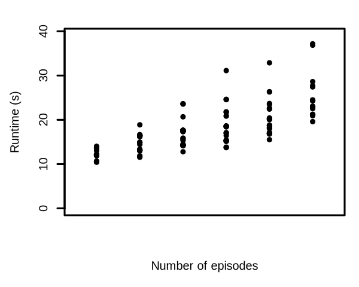

```r
min_time <- min(sapply(time_by_MOI_fix, min))
max_time <- max(sapply(time_by_MOI_fix, max))

par(cex=0.4, mar=c(5, 4.5, 2, 1))
plot(
  1, 1, type="n",
  xlim=c(1.5, maxepi + 0.5),
  ylim=c(0, max_time*1.05),
  xlab="Number of episodes",
  ylab="Runtime (s)",
  xaxt='n',
)

for(epi in 2:maxepi) {
  points(rep(epi, n_rep), time_by_MOI_fix[[epi-1]], pch=20)
}
```

With the total MOI fixed, the runtime does not increase as drastically with the number of episodes. However, more episodes still lead to more valid relationship graphs as there are less pairs of intra-episode genotypes which cannot be clones, explaining the increase in runtime.

## References

[1] Taylor AR, Foo YS, White MT. (2022). Plasmodium vivax relapse, reinfection and recrudescence estimation using genetic data. medRxiv preprint medRxiv:2022.11.23.22282669. https://doi.org/10.1101/2022.11.23.22282669